# Larriet's Notebook_EasyVisa

[figure not shown]

Data Science and Business Analytics

Ensemble Techniques and Model Tuning

[figure not shown]

Visa Approval Facilitation

# **Problem Statement**

## Context

Business communities in the United States are facing high demand for human resources, but one of the constant challenges is identifying and attracting the right talent, which is perhaps the most important element in remaining competitive. Companies in the United States look for hard-working, talented, and qualified individuals both locally as well as abroad.

The Immigration and Nationality Act (INA) of the US permits foreign workers to come to the United States to work on either a temporary or permanent basis. The act also protects US workers against adverse impacts on their wages or working conditions by ensuring US employers' compliance with statutory requirements when they hire foreign workers to fill workforce shortages. The immigration programs are administered by the Office of Foreign Labor Certification (OFLC).

OFLC processes job certification applications for employers seeking to bring foreign workers into the United States and grants certifications in those cases where employers can demonstrate that there are not sufficient US workers available to perform the work at wages that meet or exceed the wage paid for the occupation in the area of intended employment.

## Objective

In FY 2016, the OFLC processed 775,979 employer applications for 1,699,957 positions for temporary and permanent labor certifications. This was a nine percent increase in the overall number of processed applications from the previous year. The process of reviewing every case is becoming a tedious task as the number of applicants is increasing every year.

The increasing number of applicants every year calls for a Machine Learning based solution that can help in shortlisting the candidates having higher chances of VISA approval. OFLC has hired the firm EasyVisa for data-driven solutions. You as a data scientist at EasyVisa have to analyze the data provided and, with the help of a classification model:

- Facilitate the process of visa approvals.
- Recommend a suitable profile for the applicants for whom the visa should be certified or denied based on the drivers that significantly influence the case status.

## Data Description

The data contains the different attributes of employee and the employer. The detailed data dictionary is given below.

- case_id: ID of each visa application
- continent: Information of continent the employee
- education_of_employee: Information of education of the employee
- has_job_experience: Does the employee has any job experience? Y= Yes; N = No
- requires_job_training: Does the employee require any job training? Y = Yes; N = No
- no_of_employees: Number of employees in the employer's company
- yr_of_estab: Year in which the employer's company was established
- region_of_employment: Information of foreign worker's intended region of employment in the US.
- prevailing_wage: Average wage paid to similarly employed workers in a specific occupation in the area of intended employment. The purpose of the prevailing wage is to ensure that the foreign worker is not underpaid compared to other workers offering the same or similar service in the same area of employment.
- unit_of_wage: Unit of prevailing wage. Values include Hourly, Weekly, Monthly, and Yearly.
- full_time_position: Is the position of work full-time? Y = Full Time Position; N = Part Time Position
- case_status: Flag indicating if the Visa was certified or denied

## Note: This is a sample solution for the project. Projects will NOT be graded on the basis of how well the submission matches this sample solution. Projects will be graded on the basis of the rubric only.

# **Importing necessary libraries**

```python
!pip install xgboost
```

**Note**: *After running the above cell, kindly restart the notebook kernel and run all cells sequentially from the start again.*

```python
import warnings

warnings.filterwarnings("ignore")

import numpy as np
import pandas as pd
from sklearn.model_selection import train_test_split
import matplotlib.pyplot as plt
import seaborn as sns
pd.set_option("display.max_columns", None)
pd.set_option("display.max_rows", 100)
from sklearn.ensemble import (
    BaggingClassifier,
    RandomForestClassifier,
    AdaBoostClassifier,
    GradientBoostingClassifier,
    StackingClassifier,
)

from xgboost import XGBClassifier
from sklearn.tree import DecisionTreeClassifier

from sklearn import metrics
from sklearn.metrics import (
    confusion_matrix,
    accuracy_score,
    precision_score,
    recall_score,
    f1_score,
)

from sklearn.model_selection import GridSearchCV
```

```python
data = pd.read_csv('/Users/Larriet/Documents/Education/Ensemble Techniques and Model Tuning/EasyVisa.csv')
```

# **Loading the dataset**

```python
data
```

|  | case_id | continent | education_of_employee | has_job_experience | requires_job_training | no_of_employees | yr_of_estab | region_of_employment | prevailing_wage | unit_of_wage | full_time_position | case_status |
| --- | --- | --- | --- | --- | --- | --- | --- | --- | --- | --- | --- | --- |
| 0 | EZYV01 | Asia | High School | N | N | 14513 | 2007 | West | 592.2029 | Hour | Y | Denied |
| 1 | EZYV02 | Asia | Master's | Y | N | 2412 | 2002 | Northeast | 83425.6500 | Year | Y | Certified |
| 2 | EZYV03 | Asia | Bachelor's | N | Y | 44444 | 2008 | West | 122996.8600 | Year | Y | Denied |
| 3 | EZYV04 | Asia | Bachelor's | N | N | 98 | 1897 | West | 83434.0300 | Year | Y | Denied |
| 4 | EZYV05 | Africa | Master's | Y | N | 1082 | 2005 | South | 149907.3900 | Year | Y | Certified |
| ... | ... | ... | ... | ... | ... | ... | ... | ... | ... | ... | ... | ... |
| 25475 | EZYV25476 | Asia | Bachelor's | Y | Y | 2601 | 2008 | South | 77092.5700 | Year | Y | Certified |
| 25476 | EZYV25477 | Asia | High School | Y | N | 3274 | 2006 | Northeast | 279174.7900 | Year | Y | Certified |
| 25477 | EZYV25478 | Asia | Master's | Y | N | 1121 | 1910 | South | 146298.8500 | Year | N | Certified |
| 25478 | EZYV25479 | Asia | Master's | Y | Y | 1918 | 1887 | West | 86154.7700 | Year | Y | Certified |
| 25479 | EZYV25480 | Asia | Bachelor's | Y | N | 3195 | 1960 | Midwest | 70876.9100 | Year | Y | Certified |

25480 rows × 12 columns

# **Overview of the Dataset**

- Observations
- Sanity checks

```python
data.info()
```

```
<class 'pandas.core.frame.DataFrame'>
RangeIndex: 25480 entries, 0 to 25479
Data columns (total 12 columns):
 #   Column                 Non-Null Count  Dtype
---  ------                 --------------  -----
 0   case_id                25480 non-null  object
 1   continent              25480 non-null  object
 2   education_of_employee  25480 non-null  object
 3   has_job_experience     25480 non-null  object
 4   requires_job_training  25480 non-null  object
 5   no_of_employees        25480 non-null  int64
 6   yr_of_estab            25480 non-null  int64
 7   region_of_employment   25480 non-null  object
 8   prevailing_wage        25480 non-null  float64
 9   unit_of_wage           25480 non-null  object
 10  full_time_position     25480 non-null  object
 11  case_status            25480 non-null  object
dtypes: float64(1), int64(2), object(9)
memory usage: 2.3+ MB
```

```python
Row 5 , 6 and 8 has numeric values and there are 25480 rows and 12 colums in the dataset.
```

[output not shown]

```python
data.duplicated().sum()
```

```
0
```

```python
data.describe(include='all').T
```

|  | count | unique | top | freq | mean | std | min | 25% | 50% | 75% | max |
| --- | --- | --- | --- | --- | --- | --- | --- | --- | --- | --- | --- |
| case_id | 25480 | 25480 | EZYV01 | 1 | NaN | NaN | NaN | NaN | NaN | NaN | NaN |
| continent | 25480 | 6 | Asia | 16861 | NaN | NaN | NaN | NaN | NaN | NaN | NaN |
| education_of_employee | 25480 | 4 | Bachelor's | 10234 | NaN | NaN | NaN | NaN | NaN | NaN | NaN |
| has_job_experience | 25480 | 2 | Y | 14802 | NaN | NaN | NaN | NaN | NaN | NaN | NaN |
| requires_job_training | 25480 | 2 | N | 22525 | NaN | NaN | NaN | NaN | NaN | NaN | NaN |
| no_of_employees | 25480.0 | NaN | NaN | NaN | 5667.04321 | 22877.928848 | -26.0 | 1022.0 | 2109.0 | 3504.0 | 602069.0 |
| yr_of_estab | 25480.0 | NaN | NaN | NaN | 1979.409929 | 42.366929 | 1800.0 | 1976.0 | 1997.0 | 2005.0 | 2016.0 |
| region_of_employment | 25480 | 5 | Northeast | 7195 | NaN | NaN | NaN | NaN | NaN | NaN | NaN |
| prevailing_wage | 25480.0 | NaN | NaN | NaN | 74455.814592 | 52815.942327 | 2.1367 | 34015.48 | 70308.21 | 107735.5125 | 319210.27 |
| unit_of_wage | 25480 | 4 | Year | 22962 | NaN | NaN | NaN | NaN | NaN | NaN | NaN |
| full_time_position | 25480 | 2 | Y | 22773 | NaN | NaN | NaN | NaN | NaN | NaN | NaN |
| case_status | 25480 | 2 | Certified | 17018 | NaN | NaN | NaN | NaN | NaN | NaN | NaN |

```python
Most employees have job experience and a bachelors degree. Asia is the most popular place from which applicants come from.
Prevailing age averages at 74456 and most employment is from the Northeast region. large gap between the 75th percentile and the max value of no_of_employees
The min value for no_of_employees cant be -26
```

```python
data.loc[data['no_of_employees'] < 0].head()
```

|  | case_id | continent | education_of_employee | has_job_experience | requires_job_training | no_of_employees | yr_of_estab | region_of_employment | prevailing_wage | unit_of_wage | full_time_position | case_status |
| --- | --- | --- | --- | --- | --- | --- | --- | --- | --- | --- | --- | --- |
| 245 | EZYV246 | Europe | Master's | N | N | -25 | 1980 | Northeast | 39452.99 | Year | Y | Certified |
| 378 | EZYV379 | Asia | Bachelor's | N | Y | -11 | 2011 | Northeast | 32506.14 | Year | Y | Denied |
| 832 | EZYV833 | South America | Master's | Y | N | -17 | 2002 | South | 129701.94 | Year | Y | Certified |
| 2918 | EZYV2919 | Asia | Master's | Y | N | -26 | 2005 | Midwest | 112799.46 | Year | Y | Certified |
| 6439 | EZYV6440 | Asia | Bachelor's | N | N | -14 | 2013 | South | 103.97 | Hour | Y | Denied |

```python
data.loc[data['no_of_employees'] < 0].shape
```

```
(33, 12)
```

```python
data["no_of_employees"] = abs(data["no_of_employees"])
```

```python
changed
```

```python
c_col = list(data.select_dtypes("object").columns)

for column in c_col:
    print(data[column].value_counts())
    print("-" * 30)
```

```
case_id
EZYV01       1
EZYV16995    1
EZYV16993    1
EZYV16992    1
EZYV16991    1
            ..
EZYV8492     1
EZYV8491     1
EZYV8490     1
EZYV8489     1
EZYV25480    1
Name: count, Length: 25480, dtype: int64
------------------------------
continent
Asia             16861
Europe            3732
North America     3292
South America      852
Africa             551
Oceania            192
Name: count, dtype: int64
------------------------------
education_of_employee
Bachelor's     10234
Master's        9634
High School     3420
Doctorate       2192
Name: count, dtype: int64
------------------------------
has_job_experience
Y    14802
N    10678
Name: count, dtype: int64
------------------------------
requires_job_training
N    22525
Y     2955
Name: count, dtype: int64
------------------------------
```

[output cut: 10 more lines]

```
Hour      2157
Week       272
Month       89
Name: count, dtype: int64
------------------------------
full_time_position
Y    22773
N     2707
Name: count, dtype: int64
------------------------------
case_status
Certified    17018
Denied        8462
Name: count, dtype: int64
------------------------------
```

```python
The column will be droped since all the values in case_id are unique
```

```python
data.drop(['case_id'], axis=1, inplace=True)
```

# **Exploratory Data Analysis (EDA)**

- EDA is an important part of any project involving data.
- It is important to investigate and understand the data better before building a model with it.
- A few questions have been mentioned below which will help you approach the analysis in the right manner and generate insights from the data.
- A thorough analysis of the data, in addition to the questions mentioned below, should be done.

```python
def histogram_boxplot(data, feature, figsize=(12, 7), kde=False, bins=None):
    """
    Boxplot and histogram combined

    data: dataframe
    feature: dataframe column
    figsize: size of figure (default (12,7))
    kde: whether to the show density curve (default False)
    bins: number of bins for histogram (default None)
    """
    f2, (ax_box2, ax_hist2) = plt.subplots(
        nrows=2,  # Number of rows of the subplot grid= 2
        sharex=True,  # x-axis will be shared among all subplots
        gridspec_kw={"height_ratios": (0.25, 0.75)},
        figsize=figsize,
    )  # creating the 2 subplots
    sns.boxplot(
        data=data, x=feature, ax=ax_box2, showmeans=True, color="violet"
    )  # boxplot will be created and a star will indicate the mean value of the column
    sns.histplot(
        data=data, x=feature, kde=kde, ax=ax_hist2, bins=bins, palette="winter"
    ) if bins else sns.histplot(
        data=data, x=feature, kde=kde, ax=ax_hist2
    )  # For histogram
    ax_hist2.axvline(
        data[feature].mean(), color="green", linestyle="--"
    )  # Add mean to the histogram
    ax_hist2.axvline(
        data[feature].median(), color="orange", linestyle="-"
    )  # Add median to the histogram
```

**Leading Questions**

What is the distribution of visa case statuses (certified vs. denied)?

1. What is the distribution of visa case statuses (certified vs. denied)?
2. How does the education level of employees impact visa approval rates?
3. Is there a significant difference in visa approval rates between employees with and without prior job experience?
4. How does the prevailing wage affect visa approval? Do higher wages lead to higher chances of approval?
5. Do certain regions in the US have higher visa approval rates compared to others?
6. How does the number of employees in a company influence visa approval? Do larger companies have a higher approval rate?
7. Are visa approval rates different across various continents of employees? Which continent has the highest and lowest approval rates?

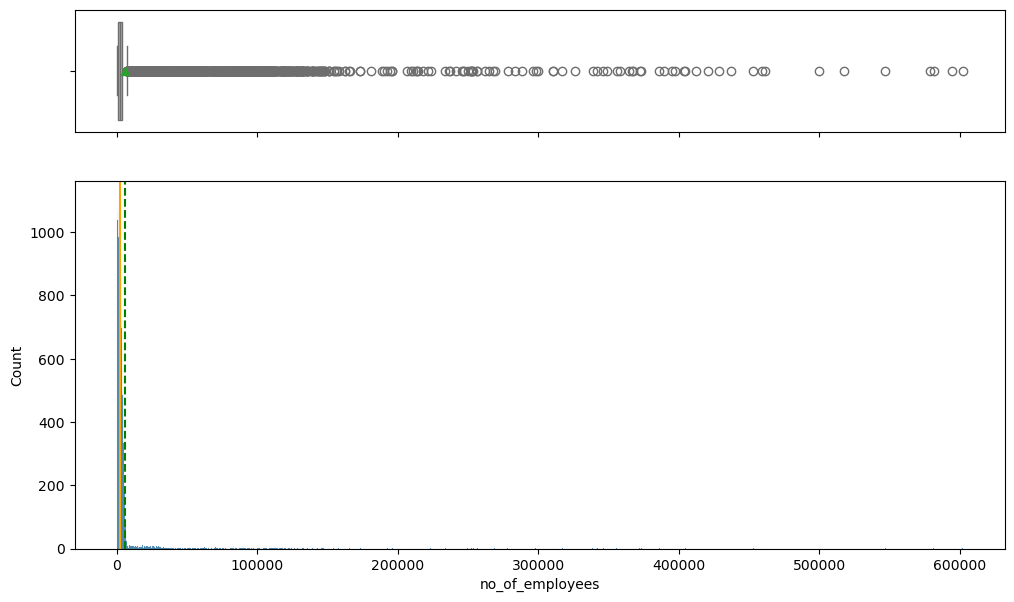

```python
histogram_boxplot(data, "no_of_employees")
```

```python
There are many outliers
```

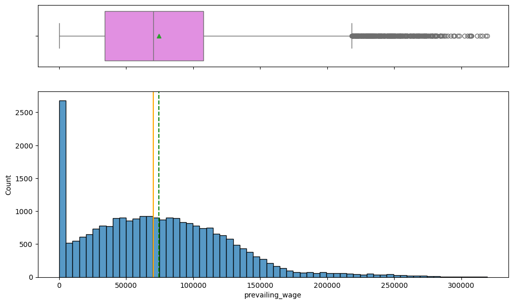

```python
histogram_boxplot(data,"prevailing_wage")
```

```python
median is the 50th percentile
```

```python
data.loc[data['prevailing_wage'] < 5000].shape
```

```
(2682, 11)
```

```python
data.loc[data['prevailing_wage'] < 100].head(10)
```

|  | continent | education_of_employee | has_job_experience | requires_job_training | no_of_employees | yr_of_estab | region_of_employment | prevailing_wage | unit_of_wage | full_time_position | case_status |
| --- | --- | --- | --- | --- | --- | --- | --- | --- | --- | --- | --- |
| 338 | Asia | Bachelor's | Y | N | 2114 | 2012 | Northeast | 15.7716 | Hour | Y | Certified |
| 634 | Asia | Master's | N | N | 834 | 1977 | Northeast | 3.3188 | Hour | Y | Denied |
| 839 | Asia | High School | Y | N | 4537 | 1999 | West | 61.1329 | Hour | Y | Denied |
| 876 | South America | Bachelor's | Y | N | 731 | 2004 | Northeast | 82.0029 | Hour | Y | Denied |
| 995 | Asia | Master's | N | N | 302 | 2000 | South | 47.4872 | Hour | Y | Certified |
| 1144 | Asia | Master's | N | N | 3542 | 2001 | Northeast | 48.0065 | Hour | Y | Denied |
| 1147 | North America | Bachelor's | Y | N | 169 | 2007 | Northeast | 99.3492 | Hour | Y | Denied |
| 1215 | Asia | Bachelor's | N | N | 1814 | 2002 | Northeast | 10.5551 | Hour | Y | Denied |
| 1238 | South America | Doctorate | N | N | 1998 | 1992 | West | 16.4637 | Hour | Y | Denied |
| 1326 | Asia | Master's | N | N | 2198 | 2004 | Northeast | 89.5992 | Hour | Y | Denied |

```python
data.loc[data["prevailing_wage"] < 100, "unit_of_wage"].value_counts()
```

```
unit_of_wage
Hour    176
Name: count, dtype: int64
```

```python
The prevailing wages that are less than 100 are on hourly pay and shows that the data is
consistent
```

```python
data.loc[data["prevailing_wage"] < 5000, "unit_of_wage"].value_counts()
```

```
unit_of_wage
Hour     2157
Year      518
Week        4
Month       3
Name: count, dtype: int64
```

```python
import pandas as pd
import seaborn as sns
import matplotlib.pyplot as plt

def labeled_barplot(data, feature):
    """
    Barplot with percentage at the top

    data: dataframe
    feature: dataframe column
    """

    total = len(data[feature])  # length of the column
    plt.figure(figsize=(8, 6))
    plt.xticks(rotation=90, fontsize=15)
    ax = sns.countplot(data=data, x=feature, palette="Paired")

    for p in ax.patches:
        label = "{:.1f}%".format(100 * p.get_height() / total)  # percentage of each category
        x = p.get_x() + p.get_width() / 2  # width of the plot
        y = p.get_height()  # height of the plot

        ax.annotate(
            label,
            (x, y),
            ha="center",
            va="center",
            size=12,
            xytext=(0, 5),
            textcoords="offset points",
        )  # annotate the percentage

    plt.xlabel(feature, fontsize=15)
    plt.ylabel("Count", fontsize=15)
    plt.title(f"Bar Plot of {feature} with Percentage", fontsize=18)
    plt.show()
```

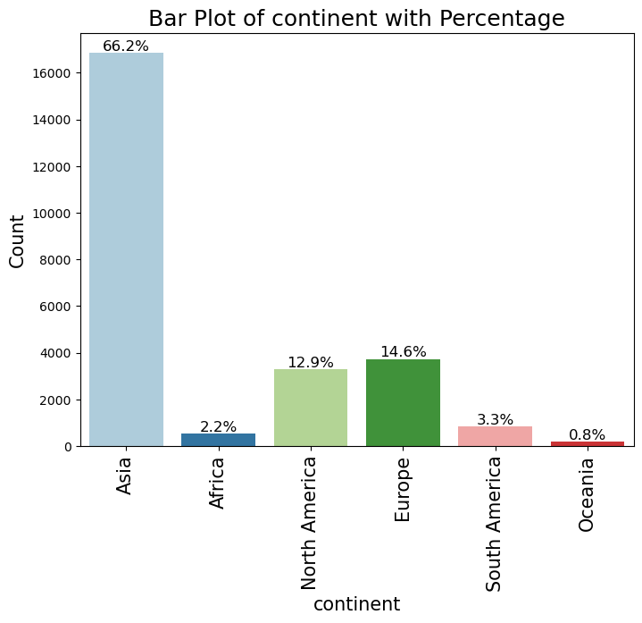

```python
labeled_barplot(data, "continent")
```

```python
More than of of the applicants are from Asia with the next highest applicant range coming from
Europe
```

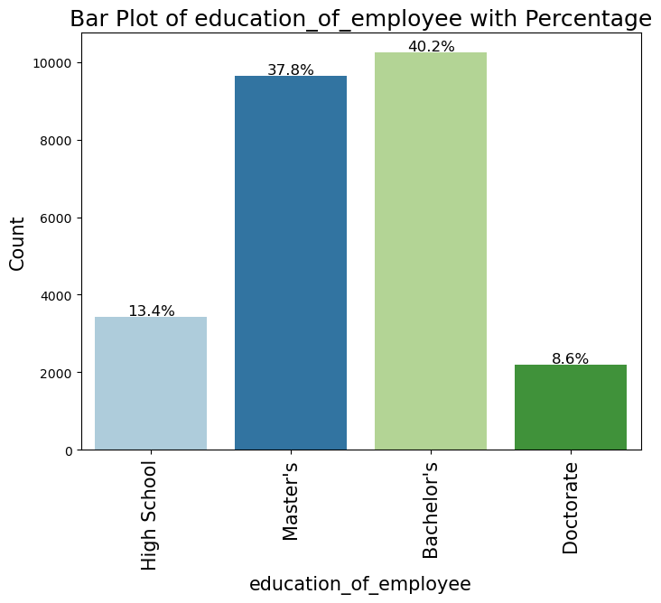

```python
labeled_barplot(data, "education_of_employee")
```

```python
Most applicants have a Bachelors or Masters degree with Bachelors as the most held.
```

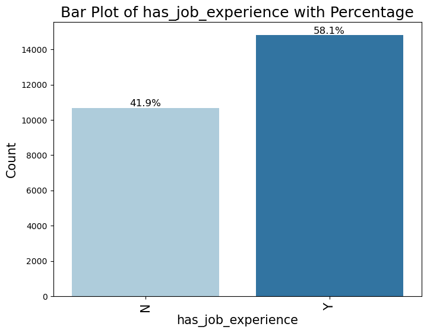

```python
labeled_barplot(data, "has_job_experience")
```

```python
More than half of the applicants have a experience
```

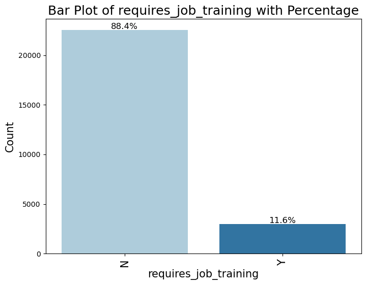

```python
labeled_barplot(data, "requires_job_training")
```

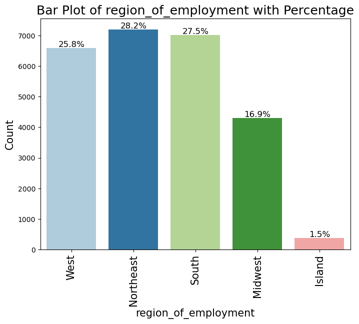

```python
labeled_barplot(data, "region_of_employment")
```

```python
South, Northeast, and West have almost equal percentages of applicants. (25%-28%) The Island
regions have only 1.5% of the applicants. The Island can be an outlier
```

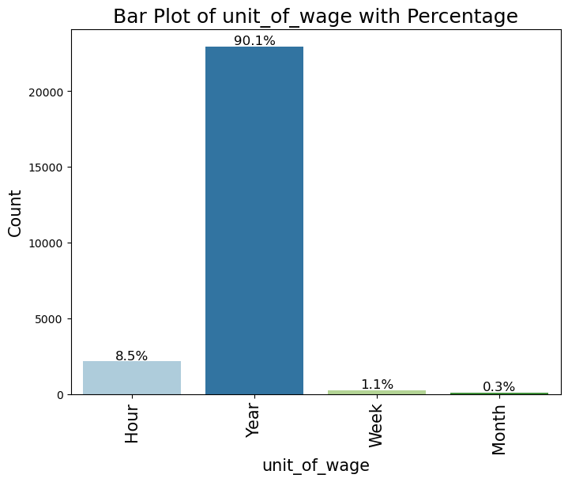

```python
labeled_barplot(data, "unit_of_wage")
```

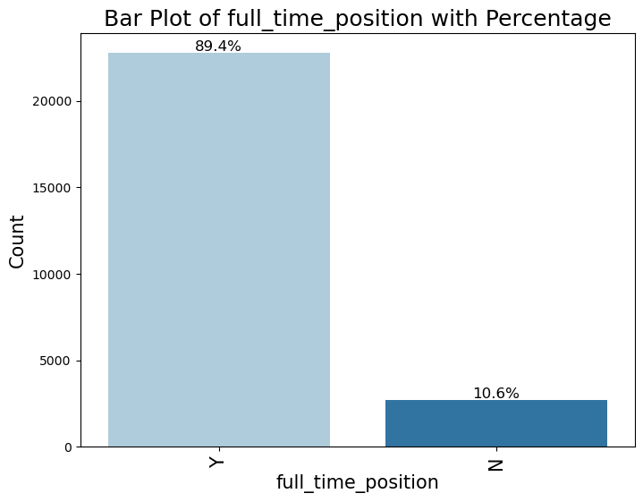

```python
labeled_barplot(data, "full_time_position")
```

```python
Most applicants apply for full time positions
```

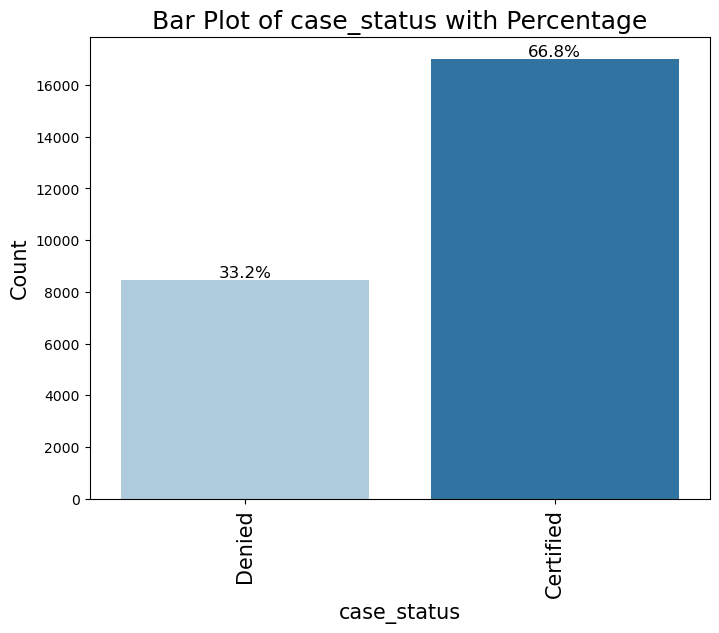

```python
labeled_barplot(data, "case_status")
```

```python
Most applicants were granted visas
```

```python
numerical_columns = data.select_dtypes(include=['int64', 'float64'])

correlation_matrix = numerical_columns.corr()

print(correlation_matrix)
```

```
                 no_of_employees  yr_of_estab  prevailing_wage
no_of_employees         1.000000    -0.017770        -0.009523
yr_of_estab            -0.017770     1.000000         0.012342
prevailing_wage        -0.009523     0.012342         1.000000
```

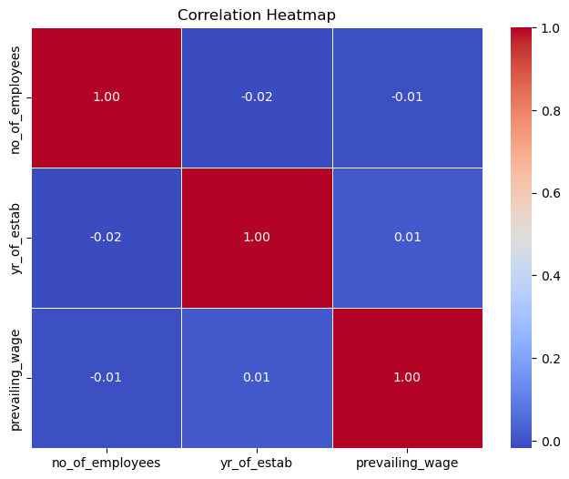

```python
plt.figure(figsize=(8, 6))
sns.heatmap(correlation_matrix, annot=True, cmap='coolwarm', fmt=".2f", linewidths=0.5)

plt.title("Correlation Heatmap")

plt.show()
```

```python
In the provided correlation matrix, the correlation coefficients are as follows :
Correlation between "yr_of_estab" and "prevailing_wage" = 0.012342
Correlation between "no_of_employees" and "yr_of_estab" = -0.017770
Correlation between "no_of_employees" and "prevailing_wage" = -0.009523
The correlation coefficient between these variables is very close to zero therefore this indicates a weak correlation or almost no linear relationship
```

```
case_status            Certified  Denied
education_of_employee
Bachelor's                  6367    3867
Doctorate                   1912     280
High School                 1164    2256
Master's                    7575    2059
```

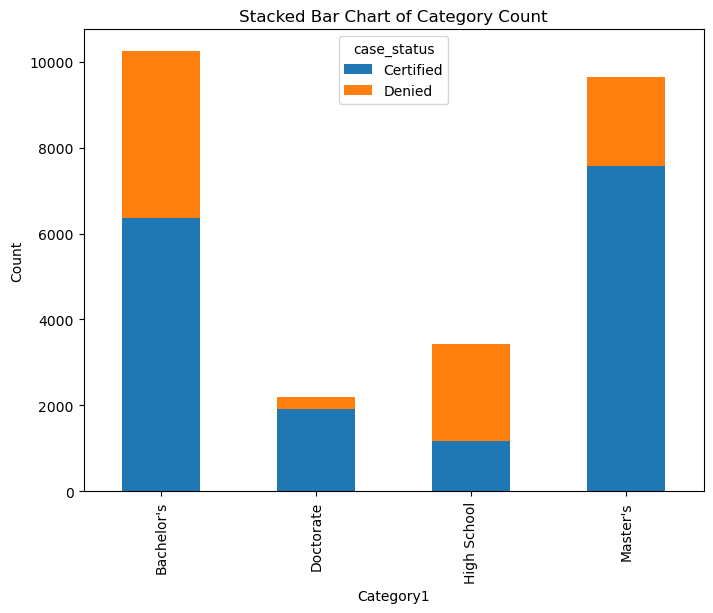

```python
category_count = pd.crosstab(data['education_of_employee'], data['case_status'])

print(category_count)

category_count.plot(kind='bar', stacked=True, figsize=(8, 6))

plt.xlabel('Category1')
plt.ylabel('Count')
plt.title('Stacked Bar Chart of Category Count')
# Show the plot
plt.show()
```